# 1 O problema das três cartas

## 1.1 Objetivo

Apresentar aos visitantes da mostra o problema das três cartas e por via dele estimular o pensamento probabilístico dos mesmos.

## 1.2 Descrição

O problema das três cartas é o seguinte:

Temos três cartas, uma com um lado vermelho e outro azul, outra com ambos os lados vermelhos e a terceira com ambos os lados azuis.

Imagine que, de maneira aleatória, uma carta foi escolhida e colocada sobre a mesa, sendo que só temos conhecimento da face que está visível.

Dado que a face visível é vermelha, ao tentar adivinhar a cor da face oposta, qual das opções é mais provável: que a face também seja vermelha, ou que a face seja azul?

## 1.3 Itens necessários

Para a realização desse experimento são necessários os seguintes itens:

- Três cartas: Uma com ambos os lados vermelhos, uma com ambos os lados azuis e outra com um lado vermelho e outro lado azul. (As cores são arbitrárias)

> Também é possível empregar uma tabela, na qual os resultados são registrados ao término do experimento. Após um número significativo de repetições, a tabela se tornará um registro das probabilidades empíricas associadas ao experimento.

## 1.4 Execução

Com as cartas em posse, pode-se seguir o seguinte roteiro:

1. Primeiramente, apresentam-se as cartas e suas faces ao participante do experimento.
2. Uma carta é selecionada aleatoriamente e colocada sobre a mesa sem que o participante a veja.
3. Com a carta postada a mesa e o participante ciente da cor de sua face superior, pergunta-se “Qual é a cor da face oposta?”.
4. Após o participante responder, pode-se continuar com “Saber a cor da face superior pode te ajudar de alguma forma a aumentar sua chance de acertar?”.
5. Por fim, a teoria é apresentada de maneira simples e clara para o participante.

O número de participantes é flexível, pois a interação de cada um ocorre por meio de palpites e comentários, possibilitando a participação simultânea de vários participantes.

## 1.5 Teoria

### 1.5.1 Modelagem matemática e eventos condicionados

Definindo que, cada uma das três cartas possui dois lados, A e B, temos

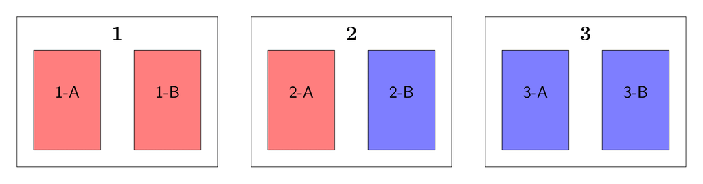

Apartir dessa definição podemos construir o seguinte modelo para o problema

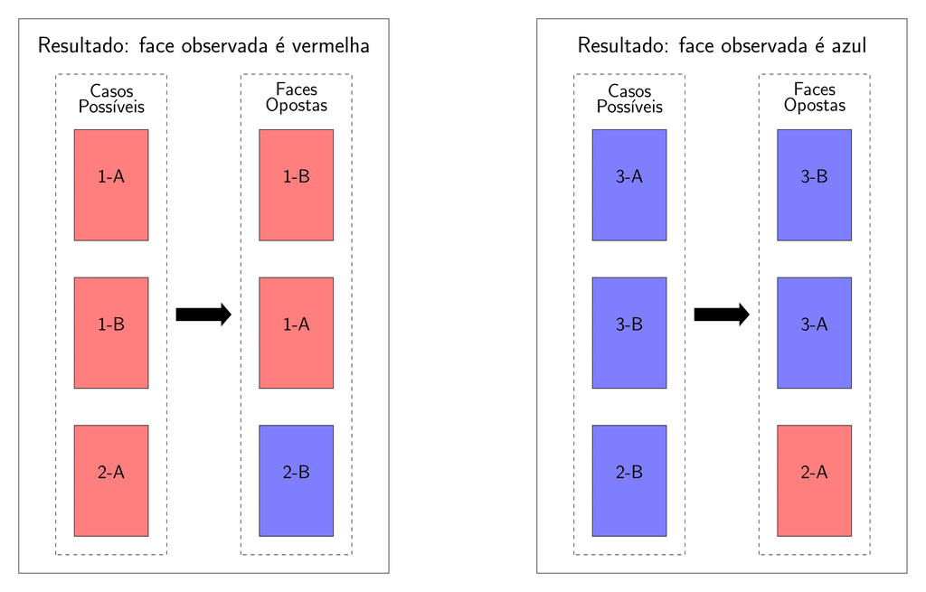

Onde a observação de cada uma das possiveis faces é equiprovavel, ou seja, cada face tem mesma chance de observação, logo quando a face visivel for vermelha a probabilidade da face oposta tambem ser vermelha é de 2/3.

> Uma outra forma de verificar esse resultado é utilizando o teorema de Bayes.

É interessante notar que, se a face superior fosse desconhecida, a probabilidade da face oposta ser vermelha seria de 1/2.

Sabendo dessas informações, temos que o evento aleatório *‘cor da face oposta’* é condicionado ao evento aleatório *‘cor da face observada’*, ou seja, a probabilidade de *‘cor da face oposta = vermelho’* muda dependendo do resultado de *‘cor da face observada’*.

> É importante ressaltar que qualquer adição ou mudança na explicação da teoria para torná-la mais clara e acessível aos participantes é bem-vinda. Diversos são os visitantes da mostra e a explicação que é óbvia para alguns pode ser confusa para outros.

## 1.6 Aplicação prática

A noção de probabilidade condicional explorada nesse experimento é uma ferramenta crucial para diversos modelos probabilísticos. É comum que um evento aleatório esteja vinculado a um acontecimento prévio, onde o comportamento probabilístico desse evento muda dependendo do resultado desse acontecimento prévio.

**Como exemplo:**

Suponha que a probabilidade de ocorrerem acidentes em uma determinada via seja um evento aleatório condicionado ao dia da semana. Foi observado que nos dias de segunda e sexta a probabilidade de acidentes é significativamente maior do que nos outros dias da semana, nesse caso seria sensato reforçar a vigilância nessa via especificamente durante esses dias. Assim, ajustando as ações de monitoramento de acordo com a variação das probabilidades, otimizando a segurança com base nos padrões identificados.

## 1.7 Referências e leituras complementares

**TALWALKAR, Presh**. “The 3 Card Riddle”, disponível em:

https://mindyourdecisions.com/blog/2016/06/19/the-3-card-riddle-sunday-puzzle/

**FRANKE, Michael**. “Probabilities & Bayes rule (in WebPPL)”, disponível em:

https://michael-franke.github.io/probLang/chapters/app-01-probability.html

**OLIVEIRA, Raul**. “Probabilidade condicional”, disponível em: https://brasilescola.uol.com.br/matematica/probabilidade-condicional.htm